# HW5-ADA

# Jing Qian (jq2282)

#### 1.a. Give the design matrix corresponding the the model $y_{ijk} = \mu+\alpha_i+\beta_j+(\alpha\beta)_{ij}+\epsilon_{ijk}$ where $\alpha_1+\alpha_2=0,\ \beta_1+\beta_2=0,\ (\alpha\beta)_{11}+(\alpha\beta)_{21}=0,\ (\alpha\beta)_{12}+(\alpha\beta)_{22}=0,\ (\alpha\beta)_{11}+(\alpha\beta)_{12}=0,\ (\alpha\beta)_{21}+(\alpha\beta)_{22}=0$.

Supposing $\alpha_1 = 1$ denotes that A is Low and $\beta_1=1$ denotes that B is New, we have $\alpha_2 = -\alpha_1,\ \beta_2 = -\beta_1,\ (\alpha\beta)_{12} = -(\alpha\beta)_{11},\ (\alpha\beta)_{21} = -(\alpha\beta)_{11},\ (\alpha\beta)_{22} = (\alpha\beta)_{11}$. So we have the design matrix as following:
$$\left[\begin{array}
{rrr}
y_{111} \\
y_{112} \\
y_{113} \\
y_{114} \\
y_{121} \\
y_{122} \\
y_{123} \\
y_{211} \\
y_{212} \\
y_{213} \\
y_{214} \\
y_{221} \\
y_{222} \\
y_{223}
\end{array}\right] = \left[\begin{array}
{rrrr}
1 & 1 & 1 & 1 \\
1 & 1 & 1 & 1 \\
1 & 1 & 1 & 1 \\
1 & 1 & 1 & 1 \\
1 & 1 & -1 & -1 \\
1 & 1 & -1 & -1 \\
1 & 1 & -1 & -1 \\
1 & -1 & 1 & -1 \\
1 & -1 & 1 & -1 \\
1 & -1 & 1 & -1 \\
1 & -1 & 1 & -1 \\
1 & -1 & -1 & 1 \\
1 & -1 & -1 & 1 \\
1 & -1 & -1 & 1
\end{array}\right]\left[\begin{array}
{rrr}
\mu \\
\alpha_1 \\
\beta_1 \\
(\alpha\beta)_{11}
\end{array}\right] + \epsilon$$

#### 1.b. Construct an interaction plot. Does it suggest that there is an interaction between fertilizer type and wheat type?

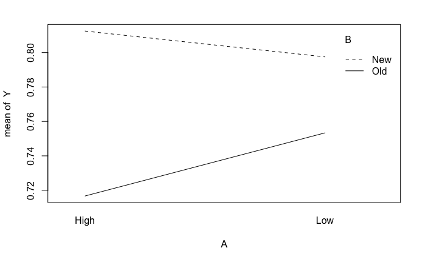

```r
interaction.plot(A, B, Y)
```

The lines in the interaction plot are not parallel to each other, which suggests that there is interaction between fertilizer type and wheat type.

#### 1.c. Test H0 : No interaction against Ha : there is an interaction, use $\alpha$ = 0.05.

```r
summary(aov(Y~A*B))
```

```
            Df  Sum Sq  Mean Sq F value Pr(>F)
A            1 0.00018 0.000179   0.046 0.8346
B            1 0.01680 0.016800   4.321 0.0643 .
A:B          1 0.00229 0.002288   0.588 0.4607
Residuals   10 0.03888 0.003888
---
Signif. codes:  0 ‘***’ 0.001 ‘**’ 0.01 ‘*’ 0.05 ‘.’ 0.1 ‘ ’ 1
```

From the ANOVA table above, we could see that p value of the test is 0.4607, which is larger than $\alpha$. So we could not reject $H_0$ and there is no interaction between A and B.

#### 1.d. It is decided to fit a model without an interaction. Test H0 : there is no A effect against Ha : there is an A effect. Use $\alpha$ = 0.05.

```r
library(car)
model<-lm(Y~A+B,contrasts=list(A=contr.sum,B=contr.sum))
Anova(model, type=3)
```

```
Anova Table (Type III tests)

Response: Y
            Sum Sq Df   F value    Pr(>F)
(Intercept) 8.1312  1 2172.4580 5.428e-14 ***
A           0.0002  1    0.0477   0.83110
B           0.0168  1    4.4885   0.05771 .
Residuals   0.0412 11
---
Signif. codes:  0 ‘***’ 0.001 ‘**’ 0.01 ‘*’ 0.05 ‘.’ 0.1 ‘ ’ 1
```

From the above ANOVA table with type III SS, we could see that the p value of the test is 0.83110, which is larger than $\alpha$. So we accept H0 and there is no A effect.

#### 1.e. It is decided to fit a model without an interaction. Test H0 : there is no B effect against Ha : there is an B effect. Use $\alpha$ = 0.05.

From the above ANOVA table with type III SS, we could see that the p value of the test is 0.05771, which is larger than $\alpha$. So we accept H0 and there is no B effect.

#### 2.a. Estimate the $\beta_i$s and interpret your result (see note for how to fit this model )

```r
y<-c(28.0,28.6,27.4,33.3,34.5,33.0,32.0,35.6,34.4,35.0,34.0,33.3,34.7,33.5,32.3,33.4,33.0,32.0,29.6,30.6,28.6,29.8)
D1<-factor(c(rep(0,3),rep(1,2),rep(0,4),rep(1,3),rep(0,3),1,rep(0,2),rep(1,2),rep(0,2)))
D2<-factor(c(rep(0,12),1,rep(0,3),rep(1,2),rep(0,2),rep(1,2)))
x1<-c(rep('A',3),rep('B',2),rep('A',4),rep('B',3),'C',rep('A',2),'B',rep('C',2),rep('B',2),rep('C',2))
x2<-c(rep(0,5),rep(1,8),rep(2,5),rep(3,4))
#data2<-data.frame(y,D1,D2,x1,x2)
#print(data2)
```

```r
fit2<-lm(y~D1+D2+x2)
summary(fit2)
```

```
Call:
lm(formula = y ~ D1 + D2 + x2)

Residuals:
    Min      1Q  Median      3Q     Max
-4.6171 -1.6321  0.5508  1.3756  4.0021

Coefficients:
            Estimate Std. Error t value Pr(>|t|)
(Intercept)  32.0171     1.0005  32.002   <2e-16 ***
D11           1.5218     1.2650   1.203    0.245
D21           0.5252     1.6194   0.324    0.749
x2           -0.4192     0.6042  -0.694    0.497
---
Signif. codes:  0 ‘***’ 0.001 ‘**’ 0.01 ‘*’ 0.05 ‘.’ 0.1 ‘ ’ 1

Residual standard error: 2.532 on 18 degrees of freedom
Multiple R-squared:  0.09453,   Adjusted R-squared:  -0.05638
F-statistic: 0.6264 on 3 and 18 DF,  p-value: 0.6072
```

When type A, the response is modelled as $Y_i = \beta_0+\beta_3x_2+\epsilon_i$; When type B, the response is modelled as $Y_i = \beta_0+\beta_1+\beta_3x_2+\epsilon_i$; When type C, the response is modelled as $Y_i = \beta_0+\beta_2+\beta_3x_2+\epsilon_i$.

The coefficient $\beta_0$ is the intercept. The coefficients $\beta_1$ and $\beta_2$ indicate with the same $x_2$, repectively, how much the reponse functions for gasoline B and gasoline C are different from the one for gasoline A. The coefficient $β_3$ represents how much $y$ increases when $x_2$ increases by one unit if other variables are fixed.

From the script above, the estimated $\beta_0=32.017,\ \beta_1=1.522,\ \beta_2=0.525,\ \beta_3=-0.419$. However, among all these $\beta_i$, only $\beta_0$ is significant while others are not. The fitted result suggests that neither premium gasoline unleaded type (A, B, C) or amount of gasoline additive VST (0, 1, 2, 3 units) has significant contribution to the gasoline mileage obtained by an automobile called Encore.

#### 2.b. Construct a 95% confidence interval for $\beta_3$ and interpret your result

```r
confint(fit2,"x2",level = 0.95)
```

```
       2.5 %    97.5 %
x2 -1.688644 0.8502126
```

The 95% confidence interval for $\beta_3$ is [-1.688644, 0.8502126], This means that we are 95% confidence that when $x_2$ increases by one unit and other variables are fixed, on average, y will change by an amount in this interval. Since the confidence interval covers 0, we could see that amount of gasoline additive VST is not a significant variable to the gasoline mileage $y$, which agrees with the conclusion in 2.a.

#### 2.c. Test H0 :$\beta_1=\beta_2=0$ against Ha :Not H0 using $\alpha$=0.05.

```r
Anova(lm(y~x1+x2),type=3)
```

```
Anova Table (Type III tests)

Response: y
            Sum Sq Df   F value Pr(>F)
(Intercept) 6567.0  1 1024.1237 <2e-16 ***
x1             9.7  2    0.7574 0.4832
x2             3.1  1    0.4814 0.4967
Residuals    115.4 18
---
Signif. codes:  0 ‘***’ 0.001 ‘**’ 0.01 ‘*’ 0.05 ‘.’ 0.1 ‘ ’ 1
```

Since $\beta_1$ and $\beta_2$ are dummy variables for variable $x_1$, we could turn the $H_0: \beta_1=\beta_2=0$ to $H_0:$ there is no $x_1$ effect. From the above ANOVA table with type III SS, we could see that the p value for the test is 0.4832, which is larger than $\alpha$. So $H_0$ could not be rejected and the premium gasoline unleaded type (A, B, C) is not a significant variable, which agrees with the concluion in 2.a.